# When Biology Meets Data Science—An Introduction to Neuroevolution

*Tim Hargreaves*

*PyData Manchester*

*23rd June 2020*

# Introduction

## About Me

- MathStat Undergraduate at University of Warwick
- Data Scientist at AstraZeneca
- Computational Statistics and Machine Learning

## Talk Objectives

### Structure

1. Introduction to evolutionary algorithms
2. Recap of neural networks
3. Application of EAs to neural networks

### Format

- High-level with links to further reading
- Source code/presentation will be linked at the end
- Chance for Q&As after talk

## Motivation

### Conventional Methods for Designing/Tuning Neural Networks

| Method | Flaws |
| --- | --- |
| Copy someone else | Requires trust/might not be appropriate |
| Use intuition | No reproducibility; requires said intuition |
| Brute force/random search | Computational complexity |
| Gradient-based methods | Lack of convexity; non-differentiable hyperparameters |
| Bayesian methods | Deciding priors/measuring convergence can be difficult |

### A Contrasting Approach

- Evolution offers a solution
- Can we implement something similar?

# Evolutionary Algorithms

## Evolution Recap

- An organism/individual is differentiated by its unique genetic code
- This genetic code will express itself in physical attributes
- These attributes impact the likelihood of survival
- Surviving organisms are more likely to reproduce
- Reproduction allows an organism to partially pass on their genes
- Mutations can occur at any time to change an organism's genes

## Components of Evolution

- Genes
- Fitness/Selection
- Cross-over/Reproduction
- Mutation

### Genes

- The smallest unit of selection
- Possible expressions of a particular gene are called alleles
- Contributes to the physical attributes of the organism

### Fitness/Selection

- Each organism has an abstract value of fitness
- This relates to its chance of survival/reproduction
- Genes that encourage fitness are more likely to disseminate

### Cross-over/Reproduction

- Two organisms can reproduce to have children
- Each child will take half their genetic material from each parent
- This loosely corresponds to 'mixing' the genes of the parents

## Mutation

- Genes can mutate to change their expression
- This can occur at any time but is more likely at birth

## Bringing it Together

[figure not shown]

## Application to Optimisation

- Genes -> Parameters
- Fitness -> Score
- Definitions of reproduction/mutation
- No one 'correct' formulation

## Example: Quadratic Regression

### Task

- Find optimal (least squares) coefficents to fit noisy quadratic data

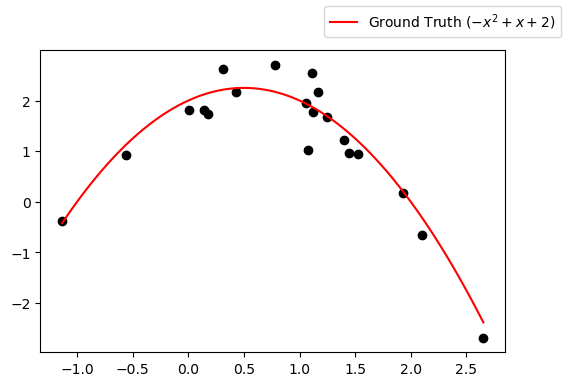

### Genes

```
gene_pool = {
    'a': (-3, 3),
    'b': (-3, 3),
    'c': (-3, 3),
}
```

```
# Initialisation
genome = {
    gene: random.uniform(alleles[0], alleles[1])
    for gene, alleles in population.gene_pool.items()
}
```

### Fitness/Selection

```
self._fitness = -np.mean(np.square(y_hat - y))
```

```
ranked_organisms = sorted(self.organisms,
                          key=lambda org: org.fitness,
                          reverse=True)

survived = ranked_organisms[:self.retain_length]
for org in ranked_organisms[self.retain_length:]:
    if len(survived) >= self.size:
        break
    if self.random_select > random.random():
        survived.append(org)

# Determine how many children to create
shortfall = self.size - len(survived)

children = []
while len(children) < shortfall:

    mother = random.choice(survived)
    father = random.choice([s for s in survived
                           if s is not mother])

    children.extend(
        Organism.breed(mother, father,
                       min(2, shortfall - len(children)))
    )

self.organisms = survived + children
```

### Cross-over/Reproduction

```
for gene in mother.population.gene_pool.keys():
    # Convex combination of parents' alleles
    p = random.random()
    genome[gene] = p * mother.genome[gene] + \
        (1-p) * father.genome[gene]
```

### Mutation

```
for gene, alleles in self.population.gene_pool.items():
    if self.population.mutation_chance > random.random():
        # Convex combination of current allele and random
        # choice from the gene pool
        p = (1 + random.random()) / 2
        self.genome[gene] = p * self.genome[gene] + \
            (1-p) * random.uniform(alleles[0], alleles[1])
```

## Results

[figure not shown]

Once Loop Reflect

[figure not shown]

Once Loop Reflect

## Comparison to Grid Search

- Grid search on integer lattice: $7^3=343$ combinations
- For precision of $0.5$ this increases to $13^3=2197$
- Evolutionary method above had $20$ organisms per generation
- Linear in number of generations
- Reasonable convergence at $5$ generations

## Comparison to Gradient Descent

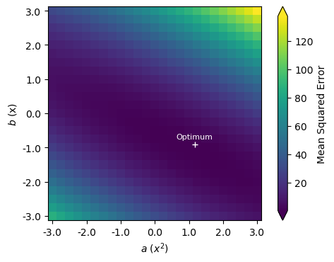

$$ \begin{align} \sum\left(y-\hat{y}'\right)^2 &:= \sum\left(y-\hat{y} + c - \hat{c}\right)^2 \\ &= \sum\left[\left(y-\hat{y}\right)^2 + \left(y-\hat{y}\right)\left(c - \hat{c}\right) + \left(c-\hat{c}\right)^2\right] \\ &= \sum\left(y-\hat{y}\right)^2 + K \qquad \left[\sum\left(y-\hat{y}\right)=0\right] \end{align}$$

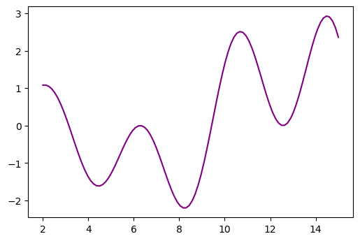

Key point: How easy is it to calculate gradients?

## Evolutionary Algorthms in the Wild

- [TSD: An extensible Evolutionary Algorithm Example in Python](https://towardsdatascience.com/an-extensible-evolutionary-algorithm-example-in-python-7372c56a557b)

[figure not shown]

- [Seth Bling](https://www.youtube.com/channel/UC8aG3LDTDwNR1UQhSn9uVrw) (based on [Evolving Neural Networks through Augmenting Topologies](http://nn.cs.utexas.edu/downloads/papers/stanley.ec02.pdf))

[figure not shown]

- [Flexible Muscle-Based Locomotion for Bipedal Creatures](https://www.cs.ubc.ca/~van/papers/2013-TOG-MuscleBasedBipeds/2013-TOG-MuscleBasedBipeds.pdf)

[figure not shown]

# Neural Networks

## Neural Network Recap

- Loosely modelled on the architecture of the brain
- Capture complex interations between inputs

[figure not shown]

### Neurons

[figure not shown]

- Also bias
- We tune the weights to improve the output

## Design Choices

### Structural

- How many layers?
- How many neurons per layer?
- Which activations?
- Types of layers? Dropout? Normalisation?

### Hyperparameters

- Learning rate?
- Batch size?
- Weight/bias initialisation?
- Which optimiser?

# Neuroevolution

## Example: MNIST

### Task

- Create a neural network that can accurately identify handwritten digits
- Network will only get a chance to see each training digit once

[figure not shown]

### Optimisation Space

- Number of layers
- Number of neurons per layer
- Whether to include bias
- Whether to use dropout/how much
- Activation types
- Optimiser

Search space size: ~10000 combinations

### Genes

```
gene_pool = {
    'num_neurons': [32, 64, 128, 256, 512, 768, 1024],
    'num_layers': [1, 2, 3, 4, 5],
    'use_bias': [True, False],
    'dropout_rate': [0., .1, .2, .3, .4],
    'activation': ['relu', 'elu', 'tanh', 'sigmoid'],
    'optimiser': ['rmsprop', 'adam', 'sgd', 'adagrad',
                  'adadelta', 'adamax', 'nadam'],
}
```

```
# Initialisation
genome = {
    gene: random.choice(alleles)
    for gene, alleles in population.gene_pool.items()
}
```

### Fitness/Selection

```
self._fitness = self.train_and_evaluate()
```

```
def train_and_evaluate(self):
    """Train this organism's model and report the final accuarcy."""
    if self.population.verbose:
        print(f"Training model {self.id}")
    # For prototype, only train for one epoch
    self.model.fit(X_train, y_train,
                   batch_size=1024,
                   epochs=1,
                   verbose=False,
                   validation_data=(X_test, y_test))

    score = self.model.evaluate(X_test, y_test, verbose=False)
    return score[1]  # accuracy
```

```
ranked_organisms = sorted(self.organisms,
                          key=lambda org: org.fitness,
                          reverse=True)

survived = ranked_organisms[:self.retain_length]
for org in ranked_organisms[self.retain_length:]:
    if len(survived) >= self.size:
        break
    if self.random_select > random.random():
        survived.append(org)

# Determine how many children to create
shortfall = self.size - len(survived)

children = []
while len(children) < shortfall:

    mother = random.choice(survived)
    father = random.choice([s for s in survived
                           if s is not mother])

    children.extend(
        Organism.breed(mother, father,
                       min(2, shortfall - len(children)))
    )

self.organisms = survived + children
```

### Cross-over/Reproduction

```
for gene in mother.population.gene_pool.keys():
    genome[gene] = random.choice((
        mother.genome[gene], father.genome[gene]
    ))
```

### Mutation

```
for gene, alleles in self.population.gene_pool.items():
    if self.population.mutation_chance > random.random():
        self.genome[gene] = random.choice(alleles)
```

## Results

[figure not shown]

Once Loop Reflect

```
num_neurons: 512
num_layers: 5
use_bias: False
dropout_rate: 0.1
activation: relu
optimiser: adam
```

## Comparison to Random Search

```
Randomly created 25 models without improvement
Randomly created 50 models without improvement
Randomly created 75 models without improvement
Randomly created 100 models without improvement
Randomly created 125 models without improvement
Randomly created 150 models without improvement
Randomly created 175 models without improvement
Randomly created 200 models without improvement
Randomly created 225 models without improvement
Randomly created 250 models without improvement
Randomly created 275 models without improvement
Randomly created 300 models without improvement
Randomly created 325 models without improvement
Randomly created 350 models without improvement
Randomly created 375 models without improvement
Randomly created 400 models without improvement
Randomly created 425 models without improvement
Randomly created 450 models without improvement
Randomly created 475 models without improvement
Randomly created 500 models without improvement
Giving up...
```

# Conclusion

## Where next?

- Productionising solution
- Experimenting with different selection/reproduction/mutation techniques
- Parallel training on multiple GPUs
- More sophisticated initialisation

## Further Reading

- [2019 Evolutionary Algorithms Review](https://arxiv.org/abs/1906.08870)
- [Evolutionary Algorithms and Neural Networks](https://www.springer.com/gb/book/9783319930244)
- [Hardmaru](https://otoro.net/ml/)

## Wrapping Up

- Source material/presentation: https://github.com/THargreaves/neuroevolution-talk
- Thank you for listening
- Any questions?